# 4.3 Array-Oriented Programming with Array

Using NumPy arrays enables you to express many kinds of data processing tasks as concise array expressions that might otherwise require writing loops. **This practice of replacing explicit loops with array expressions is commonly referred to as vectorization.**

As a simple example, suppose we wished to evaluate the function sqrt(x^2 + y^2) across a regular grid of values. The `np.meshgrid` function **takes two 1D arrays and produces two 2D matrices corresponding to all pairs of (x, y) in the two arrays:**

```python
import numpy as np
points = np.arange(-5,5,0.01) # 1000 equally spaced points
xs,ys = np.meshgrid(points,points)
ys
```

```
array([[-5.  , -5.  , -5.  , ..., -5.  , -5.  , -5.  ],
       [-4.99, -4.99, -4.99, ..., -4.99, -4.99, -4.99],
       [-4.98, -4.98, -4.98, ..., -4.98, -4.98, -4.98],
       ...,
       [ 4.97,  4.97,  4.97, ...,  4.97,  4.97,  4.97],
       [ 4.98,  4.98,  4.98, ...,  4.98,  4.98,  4.98],
       [ 4.99,  4.99,  4.99, ...,  4.99,  4.99,  4.99]])
```

Now, evaluating the function $z^2 = x^2 + y^2 $ is a matter of writing the same expression you would write with two points:

```python
z = np.sqrt(xs ** 2 + ys ** 2)
z
```

```
array([[7.07106781, 7.06400028, 7.05693985, ..., 7.04988652, 7.05693985,
        7.06400028],
       [7.06400028, 7.05692568, 7.04985815, ..., 7.04279774, 7.04985815,
        7.05692568],
       [7.05693985, 7.04985815, 7.04278354, ..., 7.03571603, 7.04278354,
        7.04985815],
       ...,
       [7.04988652, 7.04279774, 7.03571603, ..., 7.0286414 , 7.03571603,
        7.04279774],
       [7.05693985, 7.04985815, 7.04278354, ..., 7.03571603, 7.04278354,
        7.04985815],
       [7.06400028, 7.05692568, 7.04985815, ..., 7.04279774, 7.04985815,
        7.05692568]])
```

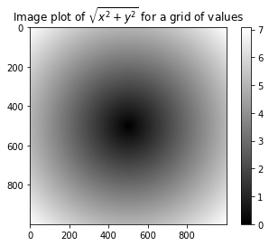

```python
import matplotlib.pyplot as plt
plt.imshow(z,cmap = plt.cm.gray);plt.colorbar()
plt.title("Image plot of $\sqrt{x^2 + y^2}$ for a grid of values")
plt.show()
```

## 1.Expressing Conditional Logic as Array Operations

The `numpy.where` function is a **vectorized version of the ternary expression** `x if condition else y`. Suppose we had a boolean array and two arrays of values:

```python
xarr = np.array([1.1, 1.2, 1.3, 1.4, 1.5])
yarr = np.array([2.1, 2.2, 2.3, 2.4, 2.5])
cond = np.array([True, False, True, True, False])
result = [(x if c else y) for x, y, c in zip(xarr, yarr, cond)]
result
```

```
[1.1, 2.2, 1.3, 1.4, 2.5]
```

```python
result = np.where(cond, xarr, yarr) # same to the above expression
result
```

```
array([1.1, 2.2, 1.3, 1.4, 2.5])
```

The second and third arguments to `np.where` **don’t need to be arrays**; one or both of them **can be scalars.**  
Suppose you had a matrix of randomly generated data and you wanted to replace all positive values with 2 and all negative values with –2. This is very easy to do with np.where:

```python
arr = np.random.randn(4,4)
arr
```

```
array([[ 0.45386623,  1.55138394,  0.84642904,  0.48547163],
       [ 0.7121255 ,  0.59419351, -0.26528977,  0.13893647],
       [ 1.41332987,  0.5915829 ,  0.08548906, -0.7223761 ],
       [ 0.54257789, -0.54644086, -0.68374047,  0.44737562]])
```

```python
result = np.where((arr>0),2,-2)
result
```

```
array([[ 2,  2,  2,  2],
       [ 2,  2, -2,  2],
       [ 2,  2,  2, -2],
       [ 2, -2, -2,  2]])
```

you can **combine scalars and arrays** when using `np.where`.

```python
np.where(arr>0,arr,0)
```

```
array([[0.45386623, 1.55138394, 0.84642904, 0.48547163],
       [0.7121255 , 0.59419351, 0.        , 0.13893647],
       [1.41332987, 0.5915829 , 0.08548906, 0.        ],
       [0.54257789, 0.        , 0.        , 0.44737562]])
```

## 2. Mathematical and Statistical Methods

A set of mathematical functions that compute statistics about an entire array or about the data along an axis are accessible as methods of the array class.  
You can use aggregations (*often called reductions*) like `sum`, `mean`, and `std` (standard deviation) either by calling the array instance method or using the top-level NumPy function.

```python
arr = np.random.randn(5,4)
arr
```

```
array([[-0.34014647, -0.76509294,  0.11363546,  2.21793225],
       [ 1.07429011, -1.01869092,  0.82609137, -0.49422208],
       [ 0.4919918 , -0.01754728, -0.39157328, -0.42877165],
       [ 0.94085463, -0.83992448, -0.29814592, -0.92787333],
       [-0.57343886,  0.1294232 , -1.41786201,  1.03616248]])
```

```python
arr.mean()
```

```
-0.034145394421569865
```

```python
np.mean(arr)
```

```
-0.034145394421569865
```

```python
arr.sum()
```

```
-0.6829078884313973
```

Functions like `mean` and `sum` take an optional `axis` argument that **computes the statistic over the given axis**, resulting in an array with one fewer dimension:

```python
arr[0,:]
```

```
array([-0.34014647, -0.76509294,  0.11363546,  2.21793225])
```

```python
np.mean(arr[0,:])
```

```
0.30658207562136086
```

```python
arr.mean(axis = 1) # calculate mean across the columns
```

```
array([ 0.30658208,  0.09686712, -0.0864751 , -0.28127227, -0.2064288 ])
```

```python
arr.sum(axis = 0)
```

```
array([ 1.59355122, -2.51183241, -1.16785437,  1.40322767])
```

Here, `arr.mean(1)` means **compute mean across the columns** where `arr.sum(0)` means **compute sum down the rows.**

Other methods like `cumsum` and `cumprod` do not aggregate, instead producing an array of the intermediate results:

```python
arr = np.array([0, 1, 2, 3, 4, 5, 6, 7])
arr.cumsum()  # cumulative sum
```

```
array([ 0,  1,  3,  6, 10, 15, 21, 28], dtype=int32)
```

```python
arr = np.array([[0, 1, 2], [3, 4, 5], [6, 7, 8]])
arr
```

```
array([[0, 1, 2],
       [3, 4, 5],
       [6, 7, 8]])
```

```python
arr.cumsum(axis = 0)  # across row
```

```
array([[ 0,  1,  2],
       [ 3,  5,  7],
       [ 9, 12, 15]], dtype=int32)
```

```python
arr.cumprod(axis = 1)
```

```
array([[  0,   0,   0],
       [  3,  12,  60],
       [  6,  42, 336]], dtype=int32)
```

#### See Table 4-5 for a full listing.

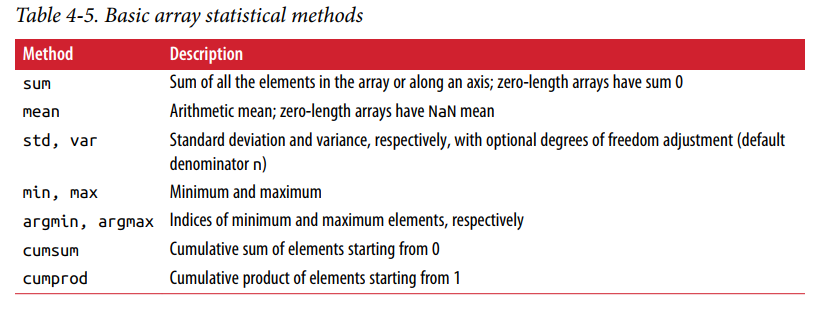

## 3. Methods for Boolean Arrays

Boolean values are coerced to 1 (True) and 0 (False) in the preceding methods. Thus,**sum is often used as a means of counting True values in a boolean array:**

```python
arr = np.random.randn(100)
arr
```

```
array([-8.56992970e-01,  8.13119611e-01,  1.17630473e+00,  3.18740837e-01,
        7.82607189e-01, -4.56756852e-01,  6.59201647e-02,  3.87786760e-02,
        1.11791056e-01,  4.29924514e-01,  1.99462349e+00,  1.80542022e+00,
       -1.52494014e-01, -1.25507205e-01,  1.12995810e+00,  1.19272524e+00,
       -2.36994750e-01,  1.30710717e+00,  1.09063290e+00, -2.55933553e-01,
        2.07847573e-01,  7.82942084e-02, -4.14137372e-01,  1.56956888e+00,
       -1.64426478e-02,  3.33226834e-02,  8.13956841e-01, -6.62722587e-01,
        1.30544297e+00, -6.27536263e-01,  1.04173677e+00,  1.43464935e-01,
       -1.64478235e-01, -4.43146639e-01, -1.97434331e+00, -3.13776172e-01,
       -8.87971248e-01, -2.62946246e-01,  4.77132368e-01,  4.69679097e-01,
        2.10271293e-01,  1.95898605e+00, -2.59236744e+00, -6.50650865e-01,
        4.02206152e-01, -1.74456157e-01, -9.02457744e-01,  1.17289737e+00,
       -3.94607886e-01,  6.91519489e-01, -4.07439558e-01, -2.00544688e-01,
        1.11578433e+00, -4.33589722e-01, -5.61747873e-01,  8.63652094e-01,
       -9.59269527e-02, -3.22818593e-01, -8.51009272e-01, -5.47252050e-01,
        7.76716752e-01, -9.43805436e-01, -7.54306780e-01,  1.84462881e+00,
        1.26158248e-01, -7.56671281e-01,  2.99349846e-01,  9.94733274e-01,
       -7.22736212e-01, -1.00930103e+00,  1.11596113e+00,  1.48237634e+00,
       -4.25190731e-01, -1.24579450e+00,  1.91818675e-02,  2.09160622e+00,
       -6.36794620e-02,  4.75144413e-01,  1.46197084e+00, -5.14032332e-01,
       -1.17185320e+00,  8.89719491e-02,  8.55378516e-01, -1.15065025e-03,
        5.08085155e-01,  7.81206876e-01, -9.73427411e-01,  8.07545580e-01,
       -9.67891166e-01, -1.16766652e+00, -1.29413199e+00, -3.65092343e-01,
        1.59137463e-01, -4.17849724e-01, -9.58505994e-01, -2.66221626e+00,
       -6.88554802e-01, -2.58367704e-01,  1.89880073e+00,  1.48263882e-01])
```

```python
(arr > 0).sum() # Number of positive values
```

```
50
```

#### There are two additional methods

- `any`: `any` tests whether one or more values in an array is True
- `all`: `all` checks if every value is True:

```python
bools = np.array([False, False, True, False])
bools.any()
```

```
True
```

```python
bools.all()
```

```
False
```

#### These methods also work with non-boolean arrays, where non-zero elements evaluate to True.

## 4. Sorting

Like Python’s built-in list type, NumPy arrays can be sorted in-place with the `sort` method:

```python
arr = np.random.randn(6)
arr
```

```
array([-0.11560514,  0.18124004,  1.36802366,  0.90757389, -0.76601859,
        0.38491852])
```

```python
arr.sort()
arr
```

```
array([-0.76601859, -0.11560514,  0.18124004,  0.38491852,  0.90757389,
        1.36802366])
```

You can sort each one-dimensional section of values in a multidimensional array **inplace along an axis by passing the axis number to sort:**

```python
arr = np.random.randn(5,3)
arr
```

```
array([[ 0.48071887,  0.4590144 , -0.08582213],
       [-0.26405762, -0.88963588,  0.10340453],
       [ 2.07606713, -0.85166958, -0.45669615],
       [-0.66647314, -1.05776948,  0.64774277],
       [-0.14205617,  0.63312079,  0.66745882]])
```

```python
arr.sort(axis = 0)
arr
```

```
array([[-0.66647314, -1.05776948, -0.45669615],
       [-0.26405762, -0.88963588, -0.08582213],
       [-0.14205617, -0.85166958,  0.10340453],
       [ 0.48071887,  0.4590144 ,  0.64774277],
       [ 2.07606713,  0.63312079,  0.66745882]])
```

The top-level method `np.sort` **returns a sorted copy** of an array instead of modifying the array in-place.

A quick-and-dirty way to **compute the quantiles** of an array is to sort it and select the value at a particular rank:

```python
large_arr = np.random.randn(1000)
large_arr.sort()
large_arr[int(0.25 * len(large_arr))]  # 25% quantile
```

```
-0.6319194094930775
```

## 5. Unique and Other Set Logic

NumPy has some basic set operations **for one-dimensional `ndarrays`**. A commonly used one is `np.unique`, which **returns the sorted unique values in an array:**

```python
names = np.array(['Bob', 'Joe', 'Will', 'Bob', 'Will', 'Joe', 'Joe'])
np.unique(names)
```

```
array(['Bob', 'Joe', 'Will'], dtype='<U4')
```

```python
ints = np.array([3, 3, 3, 2, 2, 1, 1, 4, 4])
np.unique(ints)
```

```
array([1, 2, 3, 4])
```

#### Contrast `np.unique` with the pure Python alternative:

```python
sorted(set(names))
```

```
['Bob', 'Joe', 'Will']
```

Another function, `np.in1d`, **tests membership of the values in one array in another,returning a boolean array:**

```python
values = np.array([6, 0, 0, 3, 2, 5, 6])
np.in1d(values, [0, 3, 6])
```

```
array([ True,  True,  True,  True, False, False,  True])
```

#### See Table 4-6 for a listing of set functions in NumPy

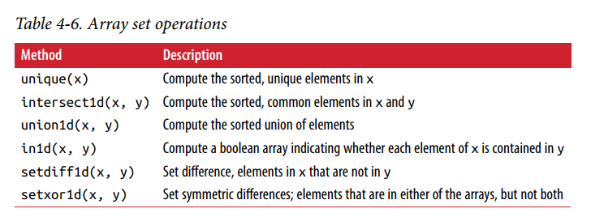